# Math 490 HW #7

Maxwell Levin

February 14, 2018

## Question 1.

#### Let $\small{X}$ be a discrete r.v. with p.m.f.: $\small{f(1) = \frac{3}{9}, f(2) = \frac{2}{9}, f(3) = \frac{1}{9}, f(4) = \frac{3}{9}}$, and let $\small{Y}$ be a discrete r.v. with p.m.f.: $\small{g(x) = \frac{1}{4}, x = 1,2,3,4}$.

#### a. Find $\small{E(X)}$ and $\small{SD(X)}$.

We calculate $\small{E(X)}$ by

$$E(X) = 1\left(\frac{3}{9}\right) + 2\left(\frac{2}{9}\right) + 3\left(\frac{1}{9}\right) + 4\left(\frac{3}{9}\right),$$
$$E(X) = \frac{22}{9} \approx 2.444.$$

We calculate $\small{Var(X)}$ by

$$Var(X) = E(X^2) - E(X)^2,$$
$$E(X^2) = 1^2\left(\frac{3}{9}\right) + 2^2\left(\frac{2}{9}\right) + 3^2\left(\frac{1}{9}\right) + 4^2\left(\frac{3}{9}\right),$$
$$E(X^2) = \frac{68}{9} \approx 7.555,$$
$$Var(X) = \frac{68}{9} - \left(\frac{22}{9}\right)^2 \approx 1.580.$$

Thus the standard deviation is

$$SD(X) = \sqrt{Var(X)} \approx 1.257.$$

#### b. Use the rejection method to sample from $\small{f(x)}$ using $\small{g(x)}$ as the proposal distribution. Apply the method with 10000 trials. Make a relative frequency table, and report the mean and the standard deviation of the simulated values.

```r
rejection = function(trials) {

  target = c(3/9, 2/9, 1/9, 3/9)
  proposal = c(1/4, 1/4, 1/4, 1/4)
  supremum = 12/9
  results = c()

  for (i in 1:trials) {
    u = runif(1)
    y = sample(1:4,1,prob=proposal)
    if (u <= target[y]/(supremum*proposal[y]) ) {
      results = c(results, y)
    }
  }
  results;
}

trials = 10000
simul = rejection(trials)
table(simul)/length(simul)
```

```
simul
        1         2         3         4
0.3289247 0.2208703 0.1165190 0.3336860
```

The mean of our simulation is:

```
[1] 2.454966
```

The standard deviation is:

```
[1] 1.254353
```

These are pretty close to what we calculated in part (a).

#### c. For the rejection sampling method used in part (b), what is the probability of acceptance?

We know from class that the probability of acceptance is given by

$$Pr\{Accept\} = \frac{1}{M},$$

where $\small{M}$ is the suprema of $\small{\frac{f(x)}{g(x)}}$. That is,

$$M = sup\left(\frac{f(x)}{g(x)}\right) = \frac{12}{9},$$
$$Pr\{Accept\} = \frac{9}{12} = \frac{3}{4}.$$

We can confirm this experimentally by dividing the length of ‘simul’ by the number of trials we’ve run:

```r
length(simul) / trials
```

```
[1] 0.7561
```

This is what we expect, wonderful!

## Question 2.

#### Let random variable $\small{X}$ have the following probability density function:

$$f(x) = \left\{
\begin{array}{ll}
\frac{x}{50} & \quad 0 \leq x \leq 10; \\
0 & \quad \text{otherwise.}
\end{array}
\right.$$

#### a. Find $\small{E(X)}$ and $\small{SD(X)}$.

We calculate $\small{E(X)}$ by

$$E(X) = \int_0^{10} \frac{x^2}{50} dx \approx 6.667.$$

We calculate $\small{Var(X)}$

$$Var(X) = E(X^2) - E(X)^2,$$
$$E(X^2) = \int_0^{10} \frac{x^3}{50} dx = 50,$$
$$Var(X) = 50 - (6.667)^2 \approx 5.556.$$

That is, $\small{SD(X)}$ is

$$SD(X) = \sqrt{Var(X)} \approx 2.357.$$

#### b. Use the rejection method to sample from $\small{f(x)}$ using Uniform(0,10) as the proposal distribution. Apply the method with 10000 trials. Make a histogram, add the density curve to the histogram, and report the mean and the standard deviation of the simulated values.

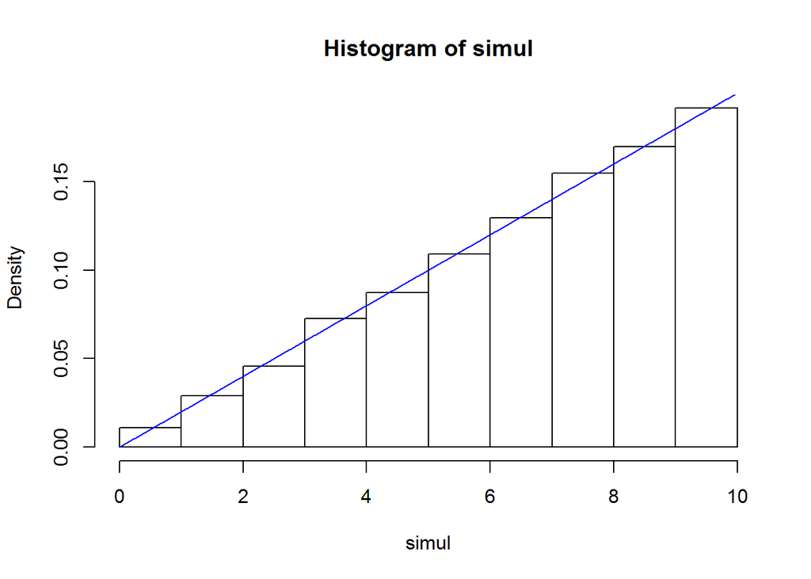

```r
target = function(x) {
        ifelse( (x >= 0 & x <= 10), x/50, 0);
}

proposal = function(x) { 0.1; }

rejCont = function(trials) {
  supremum = 2
    results <- c()
  for (i in 1:trials){
      u<-runif(1)
      y<-runif(1, 0, 10)
      if (u <= target(y) / (supremum * proposal(y)) ) {
          results = c(results, y)
      }
    }
  results;
}

trials = 10000
simul = rejCont(trials)
hist(simul, breaks=seq(0, max(simul)+1), prob=T)

x = seq(0, 10, 0.01)
y = ifelse( x >= 0 & x<= 10, x/50, 0 )
lines(x, y, col="blue")
```

The mean is

```
[1] 6.693242
```

The standard deviation is

```
[1] 2.343625
```

#### c. For the rejection sampling method used in part (b), what is the probability of acceptance?

The probability of acceptance is $\small{\frac{1}{2}}$ since 2 is the supremum (We find this occurs at $\small{x = 10}$).

We verify this experimentally:

```
[1] 0.5016
```